# Pipeline estándar: mRNA

María Araceli Hernández Betancor

24 de junio, 2020

# 1. ABSTRACT

Se analizan los datos combinados de dos estudios que nos permite comparar la expresión diferencial de genes en dos grupos étnicos, población caucásica y población africana nigeriana. Se usan los métodos implementados en el *paquete DESeq2 y EdgeR* fundamentalmente. Se concluye una expresión diferencial de utilidad en estudios evolutivos y para entender diferencias étnicas en la patogénesis de enfermedades.

# 2. OBJETIVOS

**OBJETIVOS GENERALES:** Se plantean **dos objetivos**: **1)** Utilizando los datos preparados *(dataset2)* correspondientes a la combinación de los datos de los artículos de *Montgomery* y *Pickrell* se realiza su análisis, a partir de los *read counting (count table)*. **2)** Se redacta con los resultados obtenidos un informe con la estructura tradicional de un informe técnico-científico.  
**OBJETIVOS ESPECÍFICOS:** **1)** Identificación de los genes diferencialmente expresados en los dos grupos étnicos estudiados (poblacion caucásica y africana de origen nigeriano). **2)** Análisis de la significación biológica, procesos biológicos o vías metabólicas en las que los genes diferencialmente expresados están implicados.

# 3. MATERIAL Y MÉTODOS

## 3.1. Tipo de experimento

En *PubMed* se define el experimento como un **estudio de perfil de expresión génica mediante secuenciación de alto rendimiento (RNA-seq)**. El *dataset* seleccionado es la combinación de dos estudios independientes: el estudio de *Montgomery et al* en población caucásica donde se secuencia la fracción de ARNm del transcriptoma de líneas celulares linfoblastoides de 60 individuos (CEU) combinando los datos con variantes genéticas del proyecto HapMap315, y el estudio de *Pickrell et al* en el que se realiza la secuenciación de 69 líneas celulares linfoblastoides derivadas de individuos nigerianos (YRI) no relacionados, que son genotipadas por el Proyecto Internacional HapMap. La plataforma utilizada es *Illumina Genome Analyzer II (Homo sapiens)*. Al combinar los datos de ambos estudios independientes, se obtiene un dataset con un total de 129 muestras humanas de dos grupos étnicos diferentes (60 CEU, 69 YRI) que se pueden comparar.

## 3.2. Diseño experimental

Se trata como se ha planteado de la comparación de dos grupos étnicos diferentes, dos grupos de muestras independientes, 60 de pacientes de origen europeo y 69 de origen africano nigeriano, que se combinan para estudiar su expresión genética diferencial y significación biológica. En el diseño experimental es importante diferenciar entre réplicas técnicas y biológicas. Las réplicas técnicas implican el uso de una misma muestra biológica, mismo procesado y mismos protocolos de secuenciación. Se espera que las diferencias observadas sean menores que las obtenidas con réplicas biológicas. En las réplicas biológicas se utilizan distintas muestras biológicas. En los experimentos RNA-seq, como en este caso, es más frecuente utilizar réplicas biológicas.

## 3.3. Métodos

El análisis se realizó utilizando *“DESeq, Biomart”* y *“edgeR, limma y voom”*. También se revisó la información disponible en el enlace “http:/bowtie-bio.sourceforge.net”. Se detallan en la parte de resultados para relacionarlos con los *output* obtenidos.

# 4. RESULTADOS

## 4.1. Identificación de grupos y muestras pertenecientes

Se lee y *carga* el *“dataset2.count.table”* con los datos crudos y el *phenodata* *“sampleinfo”*, se visualiza el número de muestras estudiadas y genes analizados, y se cargan los datos de *dataset2_eset.RData*. Se comprueba que se trata de **dos grupos poblacionales**, **60 muestras de pacientes caucásicos (CEU)** y **69 pacientes africanos nigerianos (YRI)**, **129 muestras en total**, donde se analizan **52580 genes**, con la función *head()* se verifica como todos los genes se identifican con identificadores ENSAMBLE, y no todos se expresan en las muestras (valor 0). Se extraen las observaciones que se corresponden con cada grupo étnico para visualizar las muestras pertenecientes a cada grupo (*sample.id*), constatando en el *phenodata* que hay una réplica por muestra para las muestras europeas y 2 para las muestras africanas, especificándose también el estudio (*study*) al que pertenece la muestra (*Montgomery*, *Pickrell*).

|  | gene | NA06985 | NA06986 | NA06994 | NA07000 | NA07037 | NA07051 | NA07346 | NA07347 | NA07357 | NA10847 | NA10851 | NA11829 | NA11830 | NA11831 | NA11832 | NA11840 | NA11881 | NA11894 | NA11918 | NA11920 | NA11931 | NA11992 | NA11993 | NA11994 | NA11995 | NA12003 | NA12004 | NA12005 | … |
| --- | --- | --- | --- | --- | --- | --- | --- | --- | --- | --- | --- | --- | --- | --- | --- | --- | --- | --- | --- | --- | --- | --- | --- | --- | --- | --- | --- | --- | --- | --- |
| 1 | ENSG00000000003 | 0 | 0 | 0 | 1 | 0 | 0 | 0 | 0 | 0 | 0 | 0 | 0 | 0 | 0 | 0 | 0 | 0 | 0 | 0 | 0 | 1 | 0 | 0 | 0 | 0 | 0 | 0 | 0 | … |
| 2 | ENSG00000000005 | 0 | 0 | 0 | 0 | 0 | 0 | 0 | 0 | 0 | 0 | 0 | 0 | 0 | 0 | 0 | 0 | 0 | 0 | 0 | 0 | 0 | 0 | 0 | 0 | 0 | 0 | 0 | 0 | … |
| 3 | ENSG00000000419 | 11 | 16 | 10 | 18 | 8 | 24 | 14 | 19 | 18 | 6 | 16 | 9 | 8 | 19 | 38 | 40 | 16 | 24 | 16 | 60 | 79 | 42 | 14 | 38 | 20 | 25 | 0 | 16 | … |
| 4 | ENSG00000000457 | 28 | 22 | 17 | 20 | 18 | 15 | 21 | 13 | 18 | 15 | 22 | 20 | 18 | 35 | 46 | 48 | 14 | 14 | 9 | 21 | 44 | 54 | 10 | 37 | 39 | 16 | 19 | 30 | … |
| 5 | ENSG00000000460 | 0 | 7 | 2 | 4 | 6 | 3 | 8 | 5 | 2 | 2 | 4 | 2 | 4 | 6 | 16 | 10 | 1 | 7 | 6 | 18 | 20 | 7 | 0 | 10 | 6 | 9 | 0 | 0 | … |
| 6 | ENSG00000000938 | 8 | 28 | 20 | 10 | 17 | 4 | 19 | 35 | 16 | 9 | 22 | 9 | 19 | 42 | 24 | 35 | 18 | 22 | 0 | 8 | 15 | 27 | 6 | 23 | 5 | 22 | 0 | 49 | … |

|  | sample.id | num.tech.reps | population | study |
| --- | --- | --- | --- | --- |
| 1 | NA06985 | 1 | CEU | Montgomery |
| 2 | NA06986 | 1 | CEU | Montgomery |
| 3 | NA06994 | 1 | CEU | Montgomery |
| 4 | NA07000 | 1 | CEU | Montgomery |
| 5 | NA07037 | 1 | CEU | Montgomery |
| 6 | NA07051 | 1 | CEU | Montgomery |

|  | sample.id | num.tech.reps | population | study |
| --- | --- | --- | --- | --- |
| 1 | NA06985 | 1 | CEU | Montgomery |
| 2 | NA06986 | 1 | CEU | Montgomery |
| 3 | NA06994 | 1 | CEU | Montgomery |
| 4 | NA07000 | 1 | CEU | Montgomery |
| 5 | NA07037 | 1 | CEU | Montgomery |
| 6 | NA07051 | 1 | CEU | Montgomery |

|  | sample.id | num.tech.reps | population | study |
| --- | --- | --- | --- | --- |
| 61 | NA18486 | 2 | YRI | Pickrell |
| 62 | NA18498 | 2 | YRI | Pickrell |
| 63 | NA18499 | 2 | YRI | Pickrell |
| 64 | NA18501 | 2 | YRI | Pickrell |
| 65 | NA18502 | 2 | YRI | Pickrell |
| 66 | NA18504 | 2 | YRI | Pickrell |

```
CEU YRI
 60  69
```

```
[1] 52580   129
```

```
 int [1:129] 1 1 1 1 1 1 1 1 1 1 ...
```

```
[1] "sample.id"     "num.tech.reps" "population"    "study"
```

```
[1] "ENSG00000000003" "ENSG00000000005" "ENSG00000000419" "ENSG00000000457"
[5] "ENSG00000000460" "ENSG00000000938"
```

```
[1] "NA06985" "NA06986" "NA06994" "NA07000" "NA07037" "NA07051"
```

Se observa la presencia de *“ruido”* en la base de datos. Los genes con recuentos muy bajos, proporcionan poca evidencia en la expresión diferencial, interfiriendo a nivel estadístico en el ajuste múltiple mediante FDR reduciendo la *“potencia estadística”* en la detección de genes diferencialmente expresados. Se expone una opción de filtrado del paquete *“edgeR”* mediante la función *“cpm()”*. Permite retener los genes si se expresan, en este ejemplo, en un conteo por millón (CPM) por encima de 0.5 en al menos dos muestras. Al convertir a CPM, se normaliza según el *“Sequencing depth”* de cada muestra, es decir según el número de lecturas que cubre cada posición. Se realiza *plot* para su representación gráfica. Como regla general, se puede elegir un umbral identificando el CPM que corresponde a un recuento de 10. Se crea un objeto *DGEList (edgeR)* para almacenar datos de recuento.

```
    0     1     2     3     4     5     6     7     8     9    10    11    12    13    14
39966   647   478   362   316   258   226   185   184   140   127   113   115    86   103
   15    16    17    18    19    20    21    22    23    24    25    26    27    28    29
   82    70    64    65    46    61    62    54    52    52    40    53    42    41    32
   30    31    32    33    34    35    36    37    38    39    40    41    42    43    44
   45    26    32    36    35    34    26    28    24    28    30    24    33    28    26
   45    46    47    48    49    50    51    52    53    54    55    56    57    58    59
   23    26    17    17    28    13    29    33    28    17    25    20    24    21    21
   60    61    62    63    64    65    66    67    68    69    70    71    72    73    74
   25    26    20    19    14    19    13    22    23    21    14    19    25    29    18
   75    76    77    78    79    80    81    82    83    84    85    86    87    88    89
   19    14    23    31    21    16    23    23    19    20    33    16    28    21    28
   90    91    92    93    94    95    96    97    98    99   100   101   102   103   104
   21    35    22    35    26    32    27    31    22    34    30    28    28    22    30
  105   106   107   108   109   110   111   112   113   114   115   116   117   118   119
   31    30    30    35    47    48    51    42    49    47    44    57    56    67    67
  120   121   122   123   124   125   126   127   128   129
   75    79    97   115   147   160   225   348   718  3931
```

```
   Mode   FALSE    TRUE
logical   40613   11967
```

```
[1] 11967   129
```

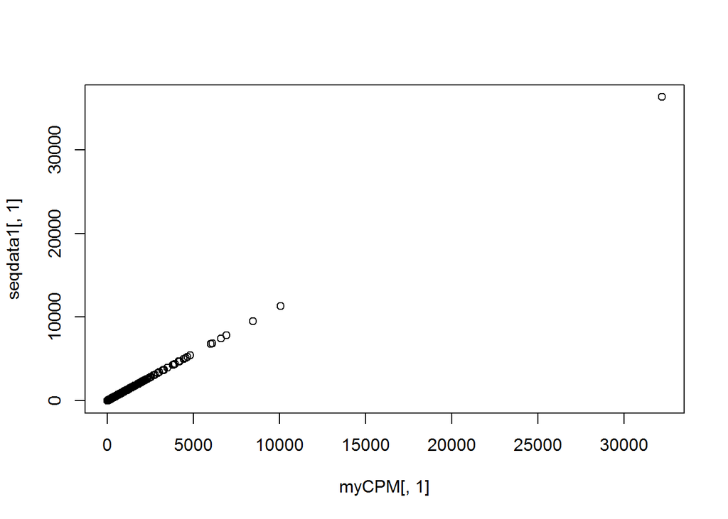

```
[1] "counts"  "samples"
```

|  | group | lib.size | norm.factors |
| --- | --- | --- | --- |
| NA06985 | 1 | 1127667 | 1 |
| NA06986 | 1 | 1172409 | 1 |
| NA06994 | 1 | 891502 | 1 |
| NA07000 | 1 | 1079934 | 1 |
| NA07037 | 1 | 1092627 | 1 |
| NA07051 | 1 | 1080636 | 1 |

Se representan los datos (*dataset2_count_table*) gráficamente a través de un histograma, descartando los genes que no se expresan. Hay unos pocos valores muy altos, se prueba a realizar una transformación logarítmica y se representan los datos transformados logarítmicamente gráficamente. Se retomará la transformación de los datos en el siguiente apartado de control de calidad.

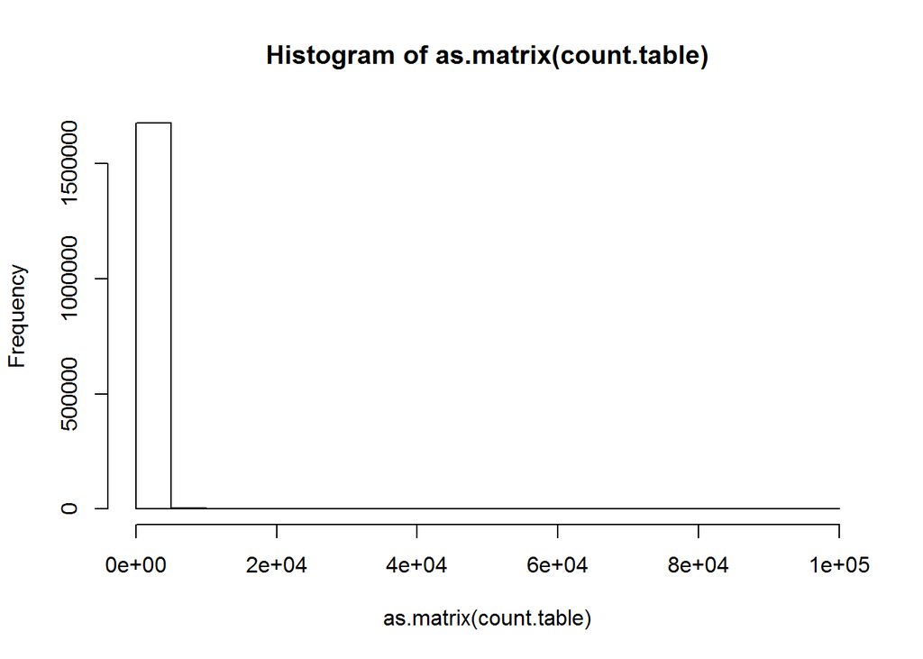

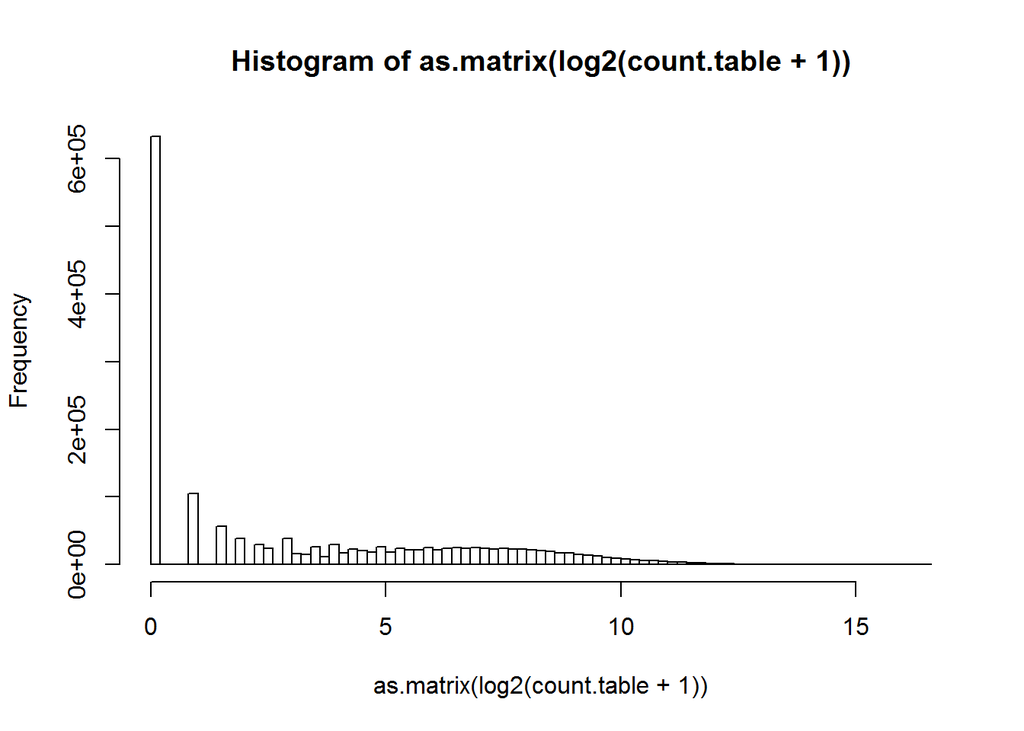

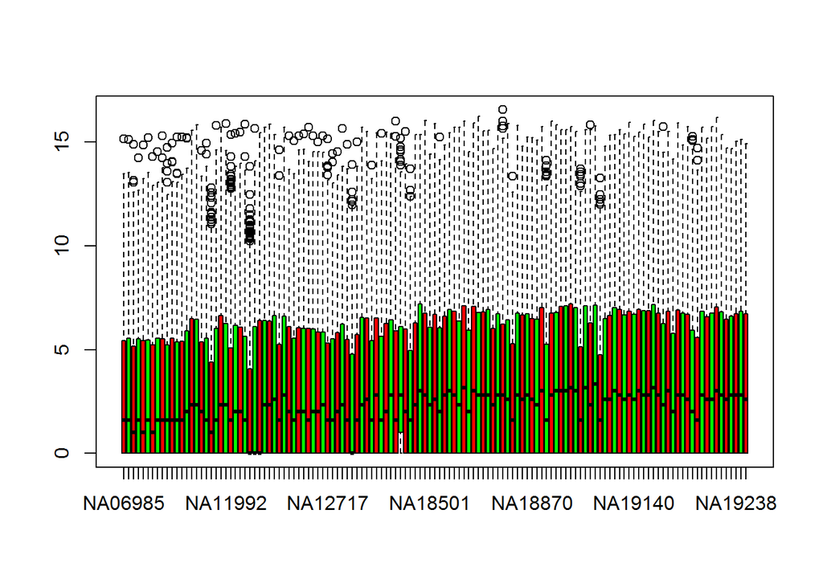

*Ensembl* es un proyecto de investigación bioinformática que trata de desarrollar un sistema de software que produzca y mantenga anotaciones automáticas en los genomas eucariotas seleccionados. El paquete *biomaRt* es un interfaz para poder acceder a una serie de bases de datos que implementan *BioMart*. Se elige utilizar *Ensembl*. Se selecciona el conjunto de datos correspondiente al ser humano. La función *useEnsembl()* permite conectarse a una base de datos y un conjunto de datos de BioMart especificados alojados por Ensembl sin tener que especificar la URL de Ensembl. Para saber qué bases de datos de BioMart están disponibles, se puede consultar la función *listEnsembl()*. La función *listAttributes()* enumera los atributos disponibles en el conjunto de datos seleccionado. La función *getBM()* es la función principal de consulta biomaRt. Dado un conjunto de filtros y valores correspondientes, recupera los atributos especificados por el usuario de la base de datos BioMart a la que está conectado. Esta anotación facilita posteriormente el reconocimiento de los genes diferencialmente expresados resultantes del uso de DEseq2.

| biomart | version |
| --- | --- |
| ensembl | Ensembl Genes 100 |
| ENSEMBL_MART_MOUSE | Mouse strains 100 |
| snp | Ensembl Variation 100 |
| regulation | Ensembl Regulation 100 |

|  | name | description | page |
| --- | --- | --- | --- |
| 10 | start_position | Gene start (bp) | feature_page |

```
[1] "TUBB"    "ZNF311"  "KIFC1"   "HSD17B8" "RNF5"    "C2"
```

## 4.2. Control de calidad de los datos crudos (*clustering*, *PCA*)

Se crea un objeto **“DESeqDataSet”** mediante la función *“DESeqDataSetFromMatrix()”* con la que se asocian los conteos y el diseño experimental para el posterior analisis de la expresión génica diferencial. A continuación se consideran solo los genes que se expresan, eliminando aquellos que presentan un valor “0”. Se reduce así el número de genes a 12984. Se transforman los datos mediante *VST* (*Variance Stabilizing Transformation*). Los datos de RNA-Seq preprocesados con *VST* son los más parecidos a los de microarrays en cuanto a distribución del coeficiente de correlación y topología *(Giorgi et al., 2013)*. Se trata de una **transformación estabilizadora de la varianza** a partir de la relación ajustada dispersión-media y posterior transformación de los datos de recuento (**normalizados** por división por los factores de tamaño o factores de normalización), produciendo una matriz de valores que ahora presentan aproximadamente homocedasticidad (varianza constante a lo largo del rango de valores medios). La transformación también se normaliza con respecto al tamaño de la *library*. El rlog es menos sensible a *“size factors”*, cuando varían ampliamente. Estas transformaciones, por ejemplo, son útiles cuando se buscan tanto **valores atípicos** como *input* para técnicas de *machine learning*, como *clustering*.

```
class: DESeqDataSet
dim: 6 129
metadata(1): version
assays(1): counts
rownames(6): TSPAN6 TNMD ... C1orf112 FGR
rowData names(0):
colnames(129): NA06985 NA06986 ... NA19239 NA19257
colData names(4): sample.id num.tech.reps population study
```

```
[1] 12984
```

Para facilitar la *diferenciación de muestras* se utilizan distintos *colores* para distinguir ambas poblaciones, añadiendo al *phenodata* denominado *sampleinfo* una nueva columna **color**.

|  | sample.id | num.tech.reps | population | study | colores |
| --- | --- | --- | --- | --- | --- |
| 1 | NA06985 | 1 | CEU | Montgomery | red |
| 2 | NA06986 | 1 | CEU | Montgomery | red |
| 3 | NA06994 | 1 | CEU | Montgomery | red |
| 4 | NA07000 | 1 | CEU | Montgomery | red |
| 5 | NA07037 | 1 | CEU | Montgomery | red |
| 6 | NA07051 | 1 | CEU | Montgomery | red |

Se presentan en **boxplot** las muestras pertenecientes a ambas poblaciones tras la transformación mediante *VST*. Se observa una mayor homogeneidad, en general, de las muestras de ambas poblaciones, a excepción de alguna muestra de la población caucásica.

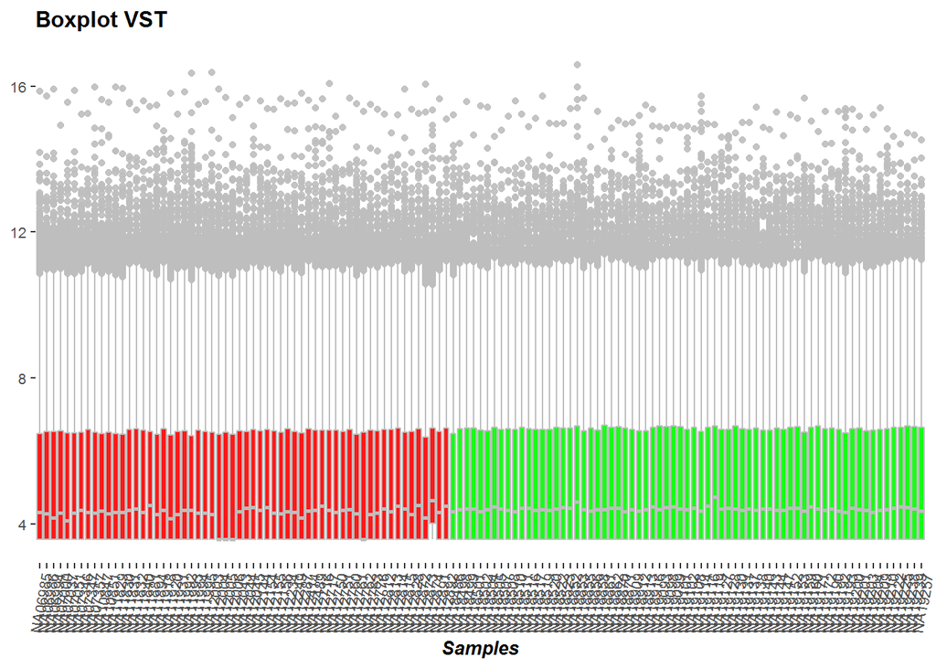

Se adjunta a continuación la representación gráfica de *PCA* tras las *transformación* de las muestras mediante *VST*. Se observa en el primer gráfico que la variabilidad se muestra fundamentalmente con los dos primeros componente (casi un 25% de la variabilidad), y se refleja mejor las diferencias entre ambas poblaciones “CEU” e “YRI” en el siguiente gráfico donde se representan las dos primeras **“PC”**.

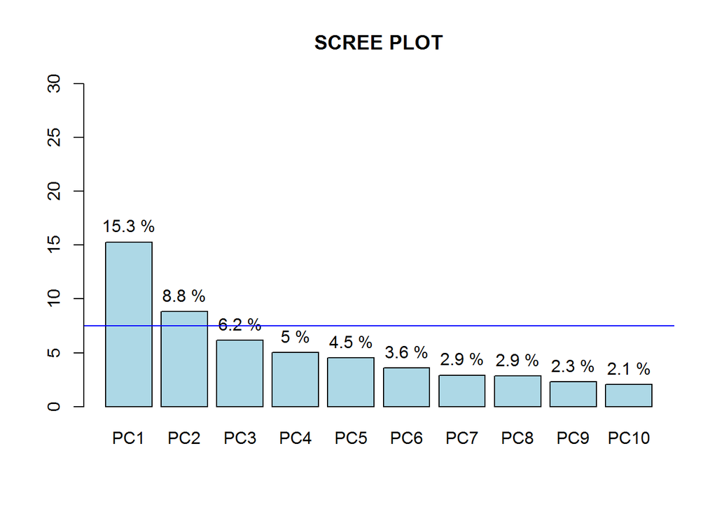

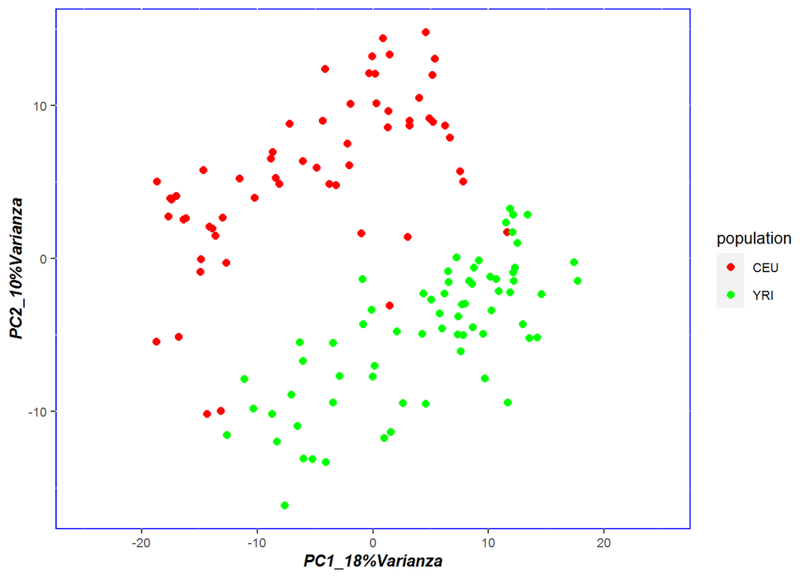

A continuación se realiza el *clustering* de las muestras transformadas *(vst)*, mediante la función *“hcut()”* que permite el *análisis jerárquico de conglomerados*. A partir de una matriz de distancia se puede trazar un dendograma para mostrar una relación jerárquica entre las muestras diferenciándose *k* grupos. Además de utilizar el agrupamiento en base a la *distancia Euclidea* (*hclust*) también acepta métodos de medición de distancia basados en correlacion de *pearson*, *spearman*, *kendall*. Al realizar el agrupamiento se observan la mayoría de las muestras de la población “YRI” en el cluster *azul*, las muestras de “CEU” se distribuyen mayoritariamente en el *“cluster”* *verde*, y en el *rojo* se ve de ambas poblaciones, pero mayoritariamente de “CEU” .

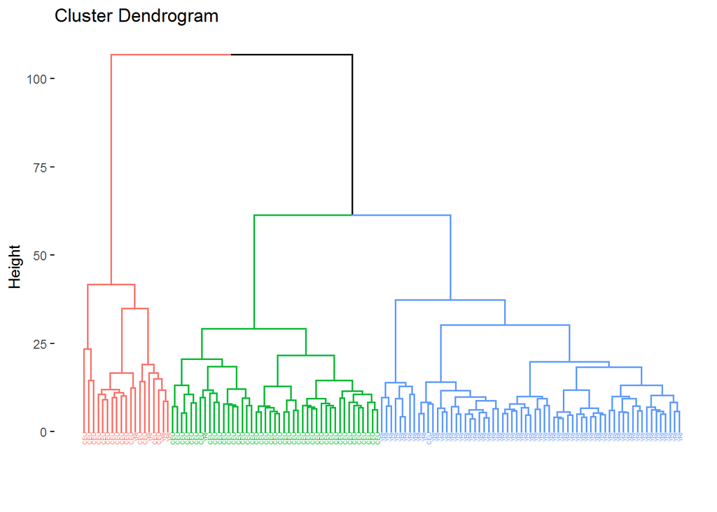

Por otro lado, se utiliza también **otra opción** para el **control de calidad**, usando el *objeto DGEList* generado previamente, se llevan a cabo algunos gráficos que informan sobre el *Quality control*. Se representan gráficamente los *“library size”* mediante un diagrama de barras para valorar discrepancias importantes entre muestras. Se prueba también a utilizar **Boxplots** para verificar la distribución de lo recuentos en escala log2. Se usa la función *cpm()* para obtener los **recuentos de log2**, corregidos por los *library sizes*. La función *cpm()* incluye una *modificación* para eliminar el problema asociado al logaritmo de valores cero. Parece que las distribuciones del *counting data* , en su mayoría, no son muy diferentes. Las muestras muy por encima o por debajo de la línea roja, es posible que merezcan una investigacion más detallada.

```
[1] 1127667 1172409  891502 1079934 1092627 1080636
```

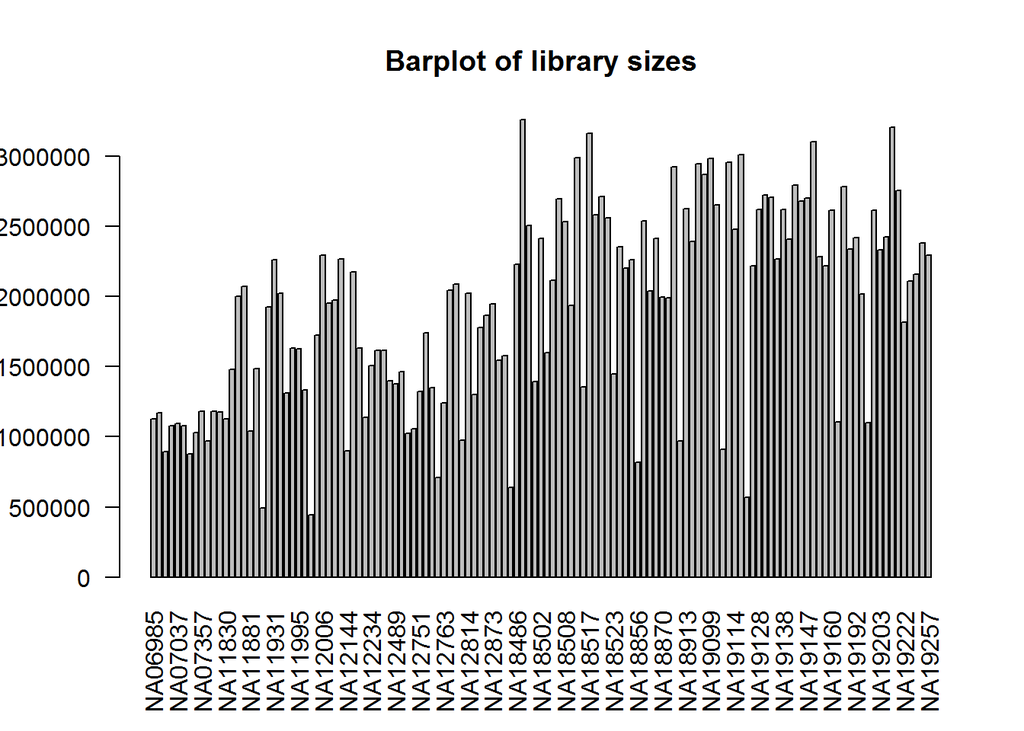

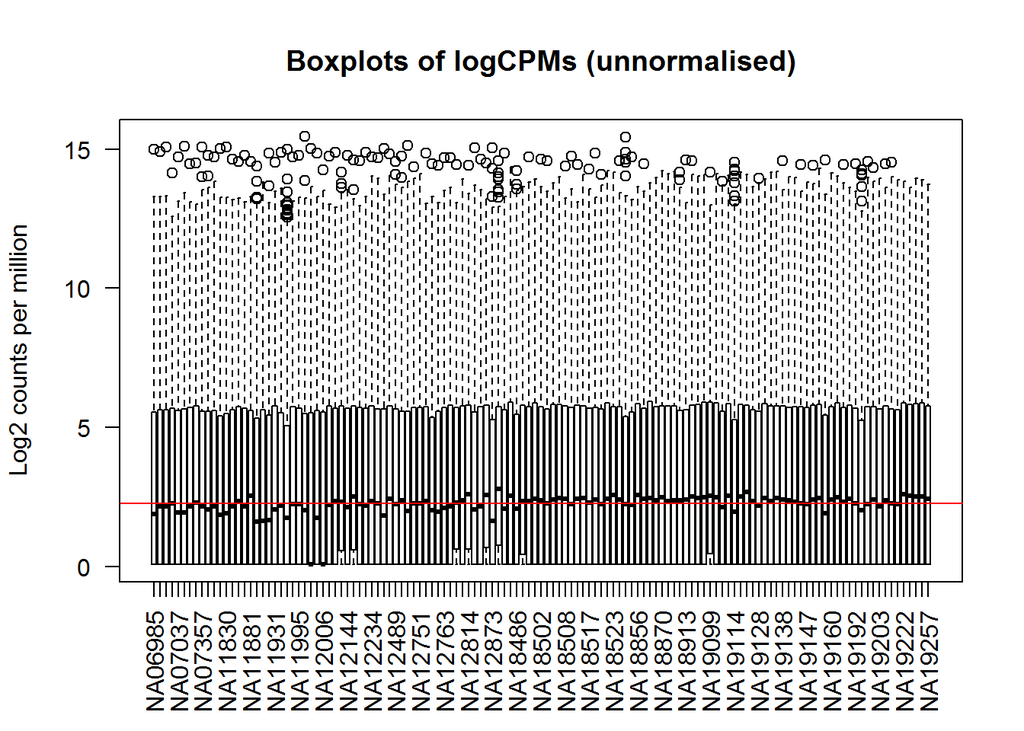

Se representan gráficamente los datos mediante un *MDSplot* para visualizar la variabilidad en los datos. Se espera ver como principal fuente de variación en los datos el grupo o **población** estudiado, que se diferencian con **dos colores**, rojo “CEU” y verde “YRI”. Resulta útil también para detectar *valores atípicos*. También puede aportar información sobre posibles efectos *batch*, teniendolo en cuenta en la *matriz de diseño*. Además es posible crear un **MDS interactivo** mediante *Glimma* (versiones interactivas de gráficos, paquete *limma*), también puede usarse en el *Volcano plot*.

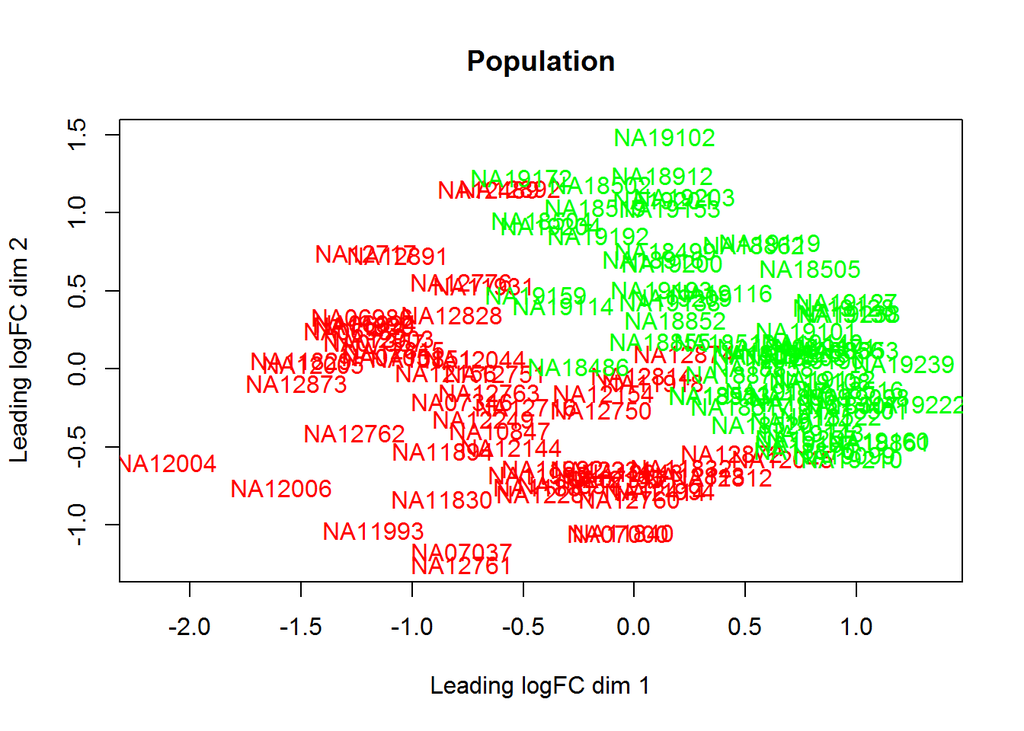

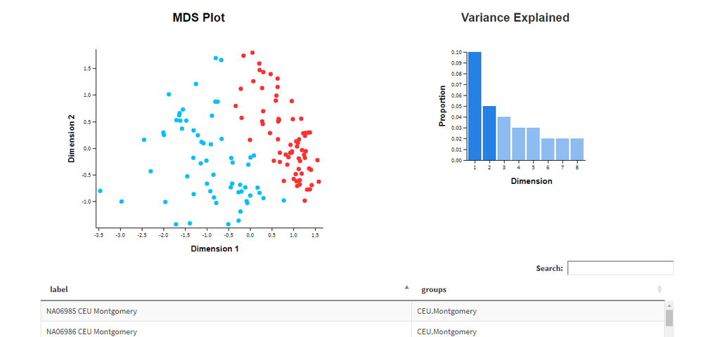

## 4.3. Normalización

En el apartado previo ya se ha realizado la nomalización de los datos mediante el uso de la función *“cpm()”* *(paquete edgeR)*, y mediante *VST* que permite transformar los datos pero también normalizarlos. De todas formas, se repite con los datos seleccionados, adjuntando los resultados, reflejando gráficamente las diferencias antes y después de la normalización mediante *boxplot*. El procedimiento de normalización (RLE) se puede implementar a traves de la función *“estimateSizeFactors()”*. El RLE dado un *“count.data”* estima los factores de tamaño dividiendo cada columna por las medias geométricas de las filas, la mediana de los cocientes se emplea como factor de tamaño para la columna *(size factor)*, omitiendo los genes con una media geométrica de cero, y se crea un objeto con los datos normalizados *cds.norm*.

```
  NA06985   NA06986   NA06994   NA07000   NA07037   NA07051
0.6274279 0.6768677 0.5052809 0.6389374 0.6262821 0.6411831
```

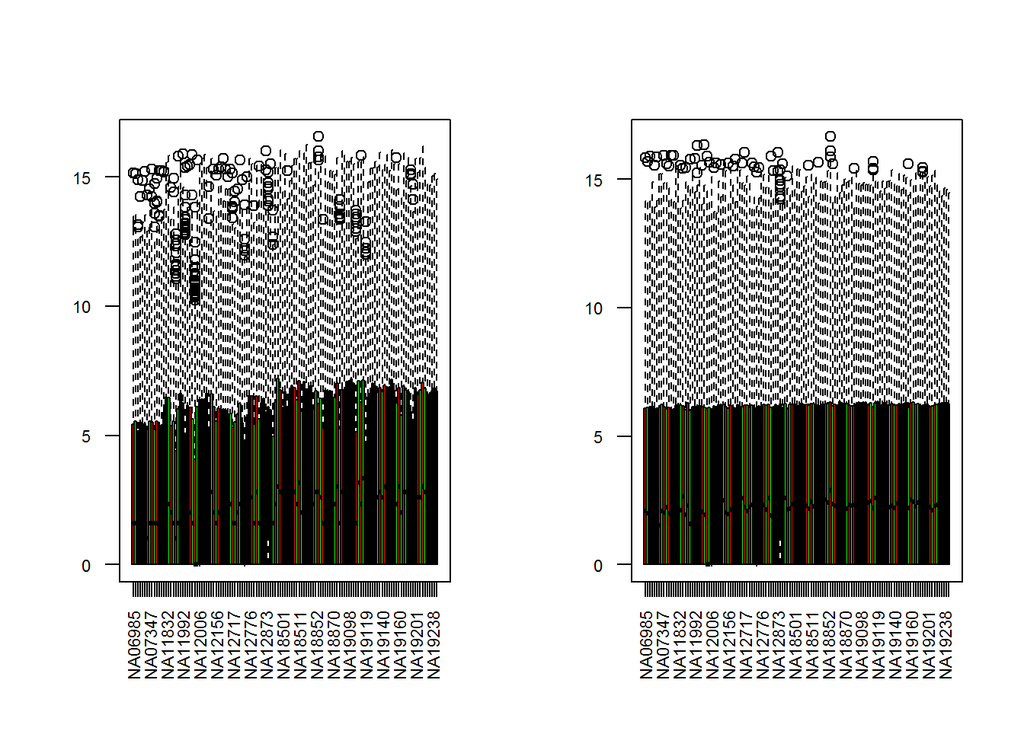

También se realiza el proceso de normalización denominado **TMM** que permite eliminar los sesgos de composición *(bias composition)* entre *libraries*. Este método genera un conjunto de factores de normalización, donde el producto de los factores y los *“library sizes”* definen el tamaño efectivo de la biblioteca *(effective library size)*. Mediante la función *“calcNormFactors()”* se pueden calcular los factores de normalización entre *“libraries”*. Un factor de normalización por debajo de uno indica que el *“library size”* se reducirá, debido a que hay más sesgo *bias composition* en esa *library* respecto a otras. Se re-escalan las recuentos *“incrementándolos”* en esa *muestra*. Un factor por encima de uno supone *“reescalar a la baja”* los recuentos. Se usan dos muestras, una con un factor de normalización más pequeño, y otra más alto. Si se realiza un gráfico de las *diferencias medias* usando la función *“plotMD()”* para dichas muestras se puede visualizar el problema de *bias composition*. Se utilizan los *logcounts*, normalizados por *“library size”*, pero no para el sesgo de composición. Los gráficos de *“diferencias de medias”* muestran la expresión promedio (media: eje x) frente a los cambios *“log-fold”* (diferencia:eje y). Como el objeto DGEList contiene los factores de normalización, si se rehacen los gráficos usando el objeto se puede resolver el sesgo de composición.

|  | group | lib.size | norm.factors |
| --- | --- | --- | --- |
| NA06985 | 1 | 1127667 | 0.9360600 |
| NA06986 | 1 | 1172409 | 0.9872981 |
| NA06994 | 1 | 891502 | 0.9784632 |
| NA07000 | 1 | 1079934 | 1.0169399 |
| NA07037 | 1 | 1092627 | 1.0079404 |
| NA07051 | 1 | 1080636 | 1.0171974 |

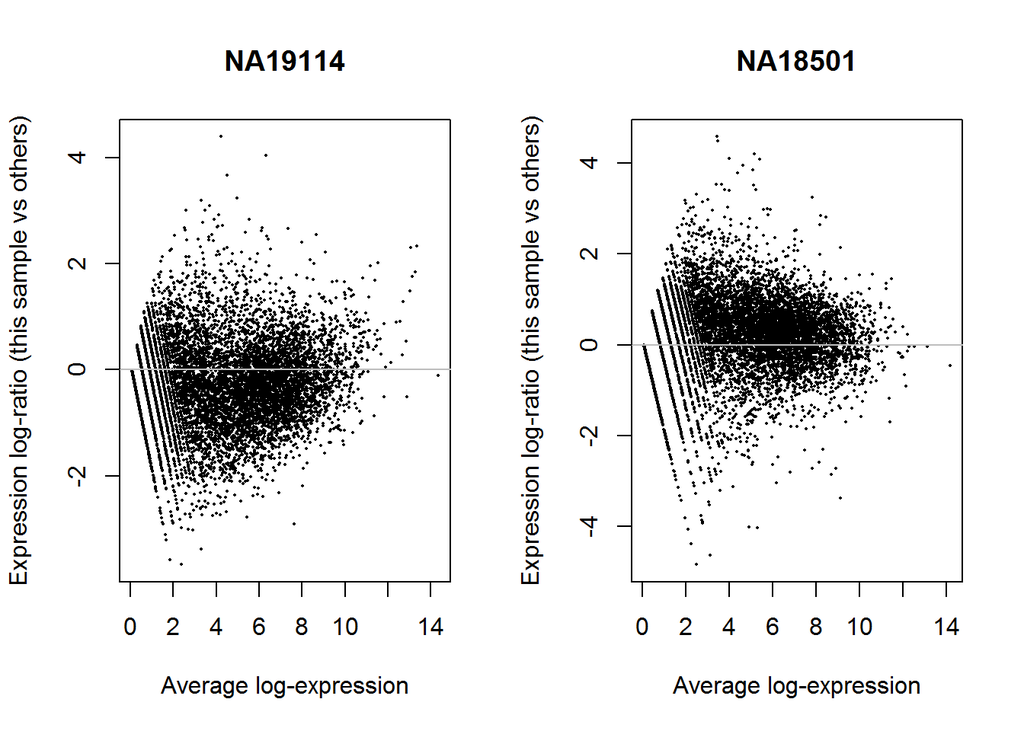

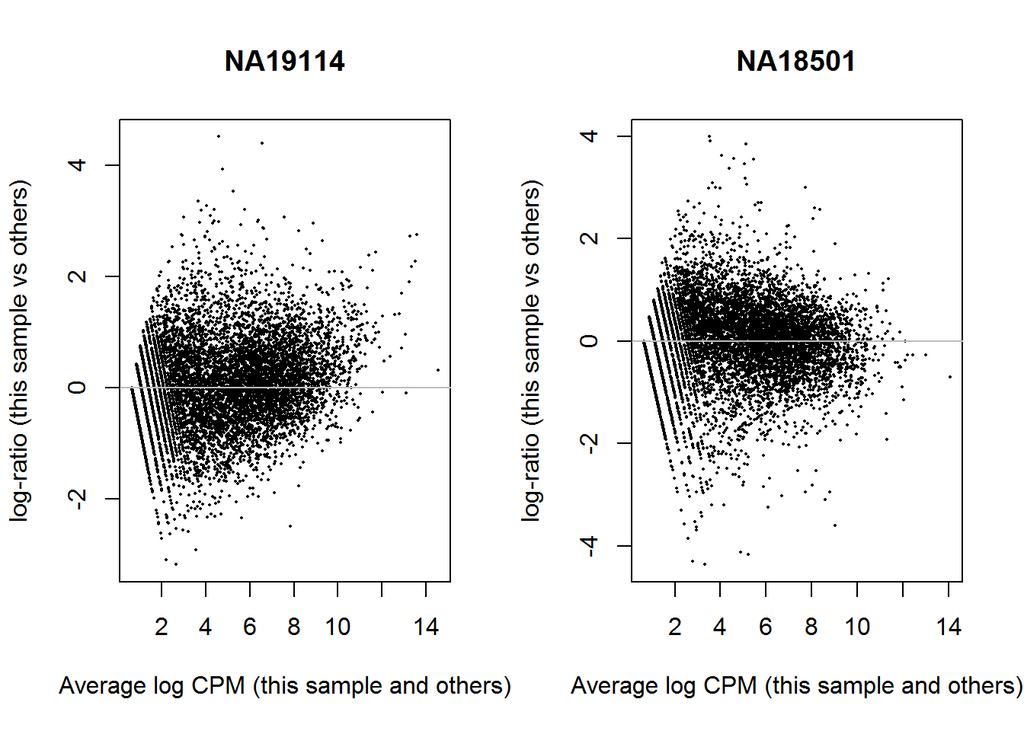

## 4.4. Identificación de genes diferencialmente expresados

Antes de identificar los genes diferencialmente expresados, mediante *“DESeq”* se *estima la dispersión* que puede utilizarse para la construcción del modelo para cada gen. Cuando se ha ajustado un modelo binomial negativo para cada gen, la función *nbinomTest()* se puede usar para evaluar la expresión diferencial. Resulta un *data.frame* que contiene valores raw p-values, y *adjusted p-values* (corrección para pruebas múltiples calculadas con el procedimiento de *Benjamini* y *Hochberg*).

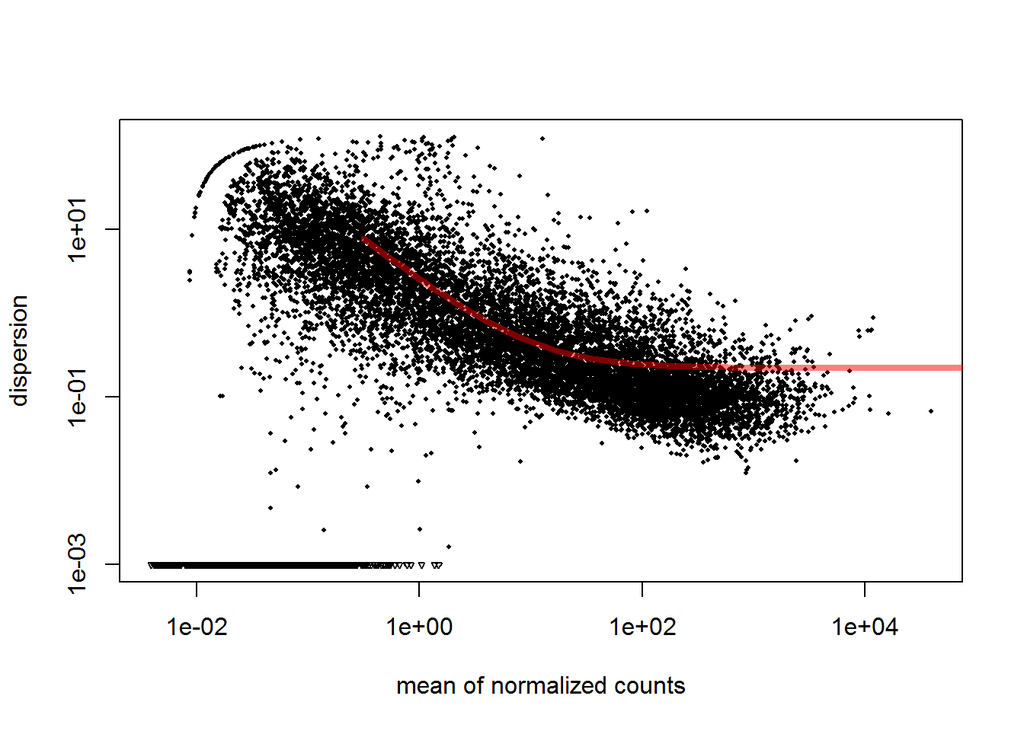

|  | id | baseMean | baseMeanA | baseMeanB | foldChange | log2FoldChange | pval | padj |
| --- | --- | --- | --- | --- | --- | --- | --- | --- |
| 8103 | 13598 | 41.326749 | 8.1668825 | 70.161416 | 8.590967 | 3.102820 | 1.231984e-53 | 1.603427e-49 |
| 4762 | 8078 | 45.427583 | 9.7584931 | 76.444184 | 7.833605 | 2.969676 | 7.902542e-42 | 5.142579e-38 |
| 5716 | 9735 | 6.604632 | 1.0676662 | 11.419384 | 10.695651 | 3.418952 | 8.910250e-36 | 3.865564e-32 |
| 4615 | 7912 | 3.628956 | 0.1877572 | 6.621303 | 35.265236 | 5.140175 | 7.900472e-33 | 2.570616e-29 |
| 8459 | 14126 | 34.241728 | 4.5712826 | 60.042116 | 13.134632 | 3.715304 | 4.539618e-31 | 1.181663e-27 |
| 4224 | 7188 | 325.899811 | 153.0653922 | 476.190610 | 3.111027 | 1.637391 | 1.321400e-29 | 2.866338e-26 |

```
[1] "populationCEU" "populationYRI"
```

```
out of 12981 with nonzero total read count
adjusted p-value < 0.1
LFC > 0 (up)       : 2626, 20%
LFC < 0 (down)     : 3002, 23%
outliers [1]       : 0, 0%
low counts [2]     : 3023, 23%
(mean count < 0)
[1] see 'cooksCutoff' argument of ?results
[2] see 'independentFiltering' argument of ?results
```

|  | baseMean | log2FoldChange | lfcSE | stat | pvalue | padj |
| --- | --- | --- | --- | --- | --- | --- |
| DPM1 | 41.784628 | -0.5576468 | 0.09848585 | -5.662203 | 1.494423e-08 | 1.028035e-07 |
| SCYL3 | 48.691924 | -0.4213438 | 0.09061460 | -4.649845 | 3.321850e-06 | 1.552743e-05 |
| FGR | 29.542373 | -0.4738877 | 0.15429238 | -3.071361 | 2.130852e-03 | 5.622626e-03 |
| RAD52 | 2.881199 | -1.0122040 | 0.21564133 | -4.693924 | 2.680139e-06 | 1.274922e-05 |
| BAD | 65.561826 | 0.6442499 | 0.08958130 | 7.191789 | 6.394760e-13 | 8.481785e-12 |
| WNT16 | 1.778989 | -1.7720726 | 0.42766522 | -4.143598 | 3.418994e-05 | 1.326708e-04 |

## 4.5. Anotación de los resultados

La anotación se había planteado en un apartado previo. A continuación se realiza la **anotación de resultados de genes** mediante *“Symbol Gene”*. La función *useEnsembl()*, como ya se ha comentado previamente, permite la conexion a una base de datos y un conjunto de datos de BioMart especificados *(“ensembl”)*. Con la función *getBM()*, dado una serie de filtros con sus valores correspondientes, se recuperan los atributos de interés. En el ejemplo *(“ensembl_gene_id”, “hgnc_symbol”, “description”, “entrezgene_id”)*. Posteriormente se ordenan los resultados obtenidos, y se asignan los nombres de *“Symbol Gene”* a las filas correspondientes. Se guarda el objeto obtenido, se ordena según *FDR*, y se muestran los resultados de las primeras filas. Esta anotación de los resultados, favorece posteriormente el reconocimiento de los genes diferencialmente expresados.

|  | GENEID | baseMean | log2FoldChange | lfcSE | stat | pvalue | padj |
| --- | --- | --- | --- | --- | --- | --- | --- |
| 1 | EFEMP2 | 44.7034 | -3.1440549 | 0.19379213 | -16.22385 | 3.420512e-59 | 3.407172e-55 |
| 2 | ZCCHC8 | 223.2986 | -1.0761175 | 0.06863907 | -15.67792 | 2.141688e-55 | 1.066668e-51 |
| 3 | INTS5 | 477.1341 | 0.8516715 | 0.05463925 | 15.58717 | 8.898243e-55 | 2.954513e-51 |
| 4 | ARHGAP9 | 500.7513 | -1.0542365 | 0.06858203 | -15.37191 | 2.526269e-53 | 6.291042e-50 |
| 5 | CENPB | 1057.2407 | 0.8680781 | 0.05655944 | 15.34807 | 3.648924e-53 | 7.269387e-50 |
| 6 | PAN2 | 339.7225 | -1.6680281 | 0.10937778 | -15.25015 | 1.642433e-52 | 2.726712e-49 |

## 4.6. Comparación entre distintas comparaciones

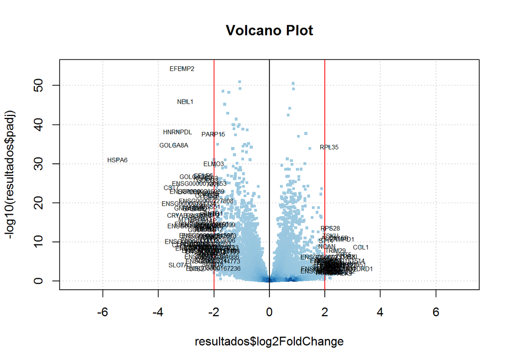

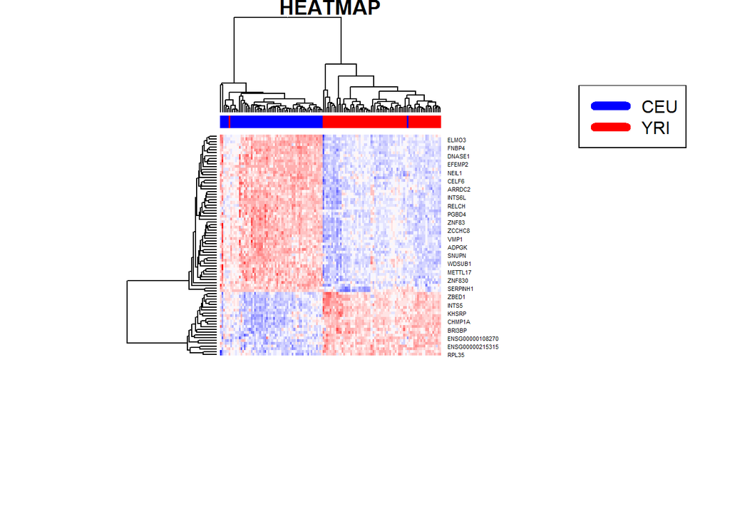

Se utiliza el *paquete limma* que ofrece la función *voom()*, que transforma los recuentos de lectura en *logCPM* teniendo en cuenta la relación de la media y varianza de datos. Se crea una matriz de diseño para los grupos poblacionales para posteriormente testar o comparar las diferencias entre grupos étnicos. *Voom* estima la tendencia de la varianza respecto a la media en el *“counting.data”*, con el objetivo de asignar un peso a cada observación según la predicción de la varianza. Los pesos se utilizan posteriormente en el modelo lineal para ajustar la heterocedasticidad. Ajusta automáticamente los *“library size”* usando los *“norm.factors”* calculados. Se produce un objeto *“Elist”*, y se genera un gráfico de la tendencia de media-varianza, que informa sobre si hay algún gen con elevada variabilidad, y si se han filtrado los bajos recuentos correctamente.Se comprueba normalidad, y se procede a realizar *“testing for differential expression”*. Se ajusta un modelo lineal para cada gen utilizando la función *“lmFit()”*. Se pretende obtener los genes diferencialmente expresados entre grupos poblacionales. La H0 es que no hay diferencias de expresión, la H1 que sí las hay entre ambos grupos étnicos. Se realiza el **contraste** comprobando una expresión diferencial de genes entre grupos poblacionales. Finalmente se obtiene **Toptable**.

```
  populationCEU populationYRI
1             1             0
2             1             0
3             1             0
4             1             0
5             1             0
6             1             0
```

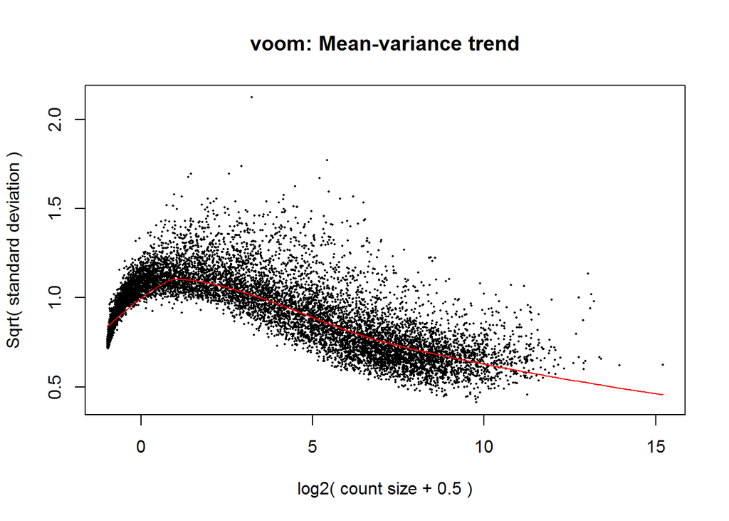

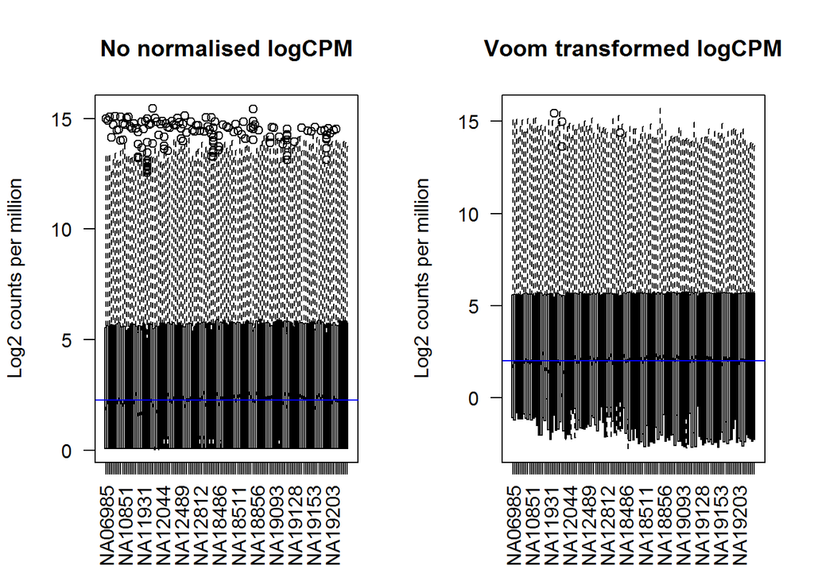

```
  CEU YRI
1   1   0
2   1   0
3   1   0
4   1   0
5   1   0
6   1   0
```

```
      Contrasts
Levels CEUvsYRI
   CEU        1
   YRI       -1
```

```
       CEUvsYRI
Down       2914
NotSig     3733
Up         5320
```

|  | logFC | AveExpr | t | P.Value | adj.P.Val | B |
| --- | --- | --- | --- | --- | --- | --- |
| 7912 | -2.885401 | 0.378894 | -20.19342 | 1.230703e-42 | 1.472783e-38 | 85.76854 |
| 14126 | -4.416330 | 2.713509 | -19.06538 | 3.920069e-40 | 2.345573e-36 | 80.13987 |
| 13598 | -3.670911 | 3.473892 | -17.15221 | 9.923498e-36 | 3.958483e-32 | 70.28308 |
| 9735 | -3.037772 | 1.091479 | -16.81582 | 6.178334e-35 | 1.848403e-31 | 68.54121 |
| 3582 | -1.529528 | 6.384580 | -16.43107 | 5.085190e-34 | 1.217089e-30 | 66.83145 |
| 7188 | -1.745255 | 7.189184 | -15.70314 | 2.871257e-32 | 5.726723e-29 | 62.81794 |
| 903 | -1.323705 | 7.798917 | -15.59365 | 5.293133e-32 | 9.048989e-29 | 62.18277 |
| 16607 | -1.532486 | 5.071793 | -15.35557 | 2.010202e-31 | 2.946748e-28 | 60.86655 |
| 506 | -1.022411 | 6.810298 | -15.33821 | 2.216156e-31 | 2.946748e-28 | 60.79179 |
| 3770 | -1.160009 | 8.329855 | -15.27112 | 3.231707e-31 | 3.867384e-28 | 60.35134 |

## 4.7. Análisis de significación biológica (*“Gene Enrichment Analysis”*)

|  | ID | Description | Count | GeneRatio | geneID |
| --- | --- | --- | --- | --- | --- |
| GO:0019953 | GO:0019953 | sexual reproduction | 0 | 0/1 |  |
| GO:0019954 | GO:0019954 | asexual reproduction | 0 | 0/1 |  |
| GO:0022414 | GO:0022414 | reproductive process | 0 | 0/1 |  |
| GO:0032504 | GO:0032504 | multicellular organism reproduction | 0 | 0/1 |  |
| GO:0032505 | GO:0032505 | reproduction of a single-celled organism | 0 | 0/1 |  |
| GO:0061887 | GO:0061887 | reproduction of symbiont in host | 0 | 0/1 |  |
| GO:0055114 | GO:0055114 | oxidation-reduction process | 0 | 0/1 |  |
| GO:0006807 | GO:0006807 | nitrogen compound metabolic process | 0 | 0/1 |  |
| GO:0009056 | GO:0009056 | catabolic process | 0 | 0/1 |  |
| GO:0009058 | GO:0009058 | biosynthetic process | 0 | 0/1 |  |

[output cut: 548 more lines]

|  | ID | Description | GeneRatio | BgRatio | pvalue | p.adjust | qvalue | geneID | Count |
| --- | --- | --- | --- | --- | --- | --- | --- | --- | --- |
| GO:0051965 | GO:0051965 | positive regulation of synapse assembly | 1/1 | 66/17913 | 0.003684475 | 0.01445877 | NA | FLRT1 | 1 |
| GO:0051963 | GO:0051963 | regulation of synapse assembly | 1/1 | 105/17913 | 0.005861665 | 0.01445877 | NA | FLRT1 | 1 |
| GO:0008543 | GO:0008543 | fibroblast growth factor receptor signaling pathway | 1/1 | 109/17913 | 0.006084966 | 0.01445877 | NA | FLRT1 | 1 |
| GO:0044344 | GO:0044344 | cellular response to fibroblast growth factor stimulus | 1/1 | 138/17913 | 0.007703902 | 0.01445877 | NA | FLRT1 | 1 |
| GO:0071774 | GO:0071774 | response to fibroblast growth factor | 1/1 | 145/17913 | 0.008094680 | 0.01445877 | NA | FLRT1 | 1 |
| GO:1990138 | GO:1990138 | neuron projection extension | 1/1 | 148/17913 | 0.008262156 | 0.01445877 | NA | FLRT1 | 1 |
| GO:0007416 | GO:0007416 | synapse assembly | 1/1 | 172/17913 | 0.009601965 | 0.01445877 | NA | FLRT1 | 1 |
| GO:0060560 | GO:0060560 | developmental growth involved in morphogenesis | 1/1 | 214/17913 | 0.011946631 | 0.01445877 | NA | FLRT1 | 1 |
| GO:0016358 | GO:0016358 | dendrite development | 1/1 | 216/17913 | 0.012058282 | 0.01445877 | NA | FLRT1 | 1 |
| GO:0048588 | GO:0048588 | developmental cell growth | 1/1 | 216/17913 | 0.012058282 | 0.01445877 | NA | FLRT1 | 1 |

[output cut: 4 more lines]

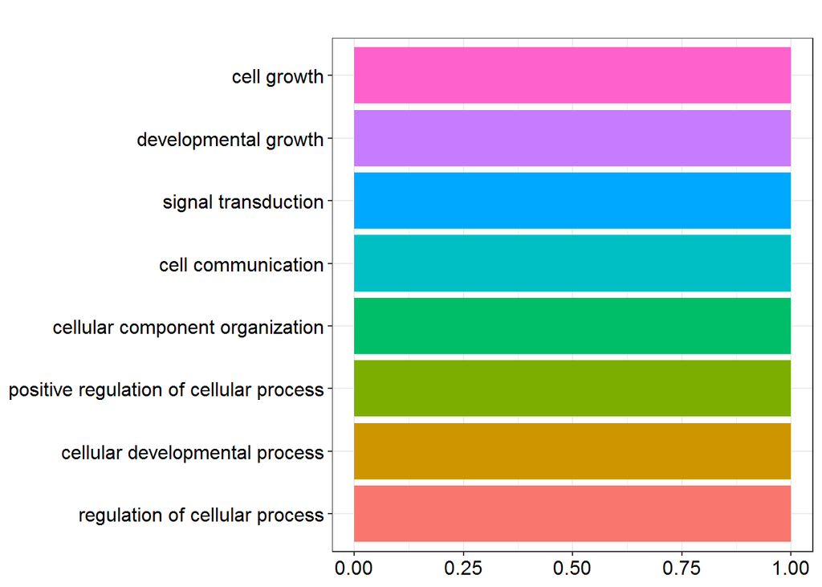

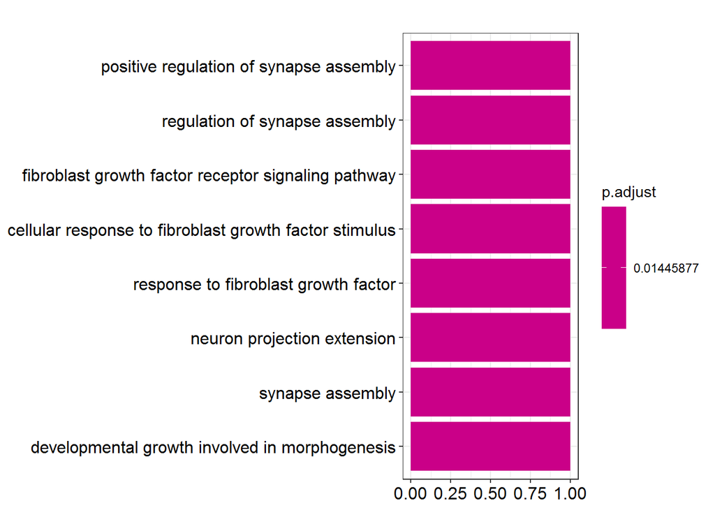

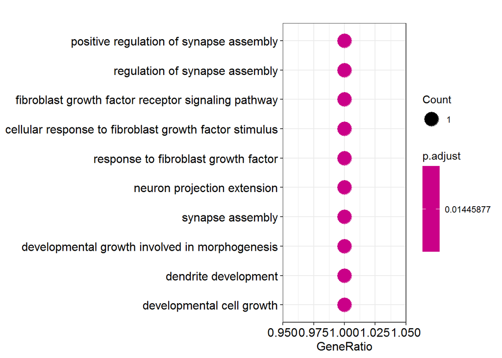

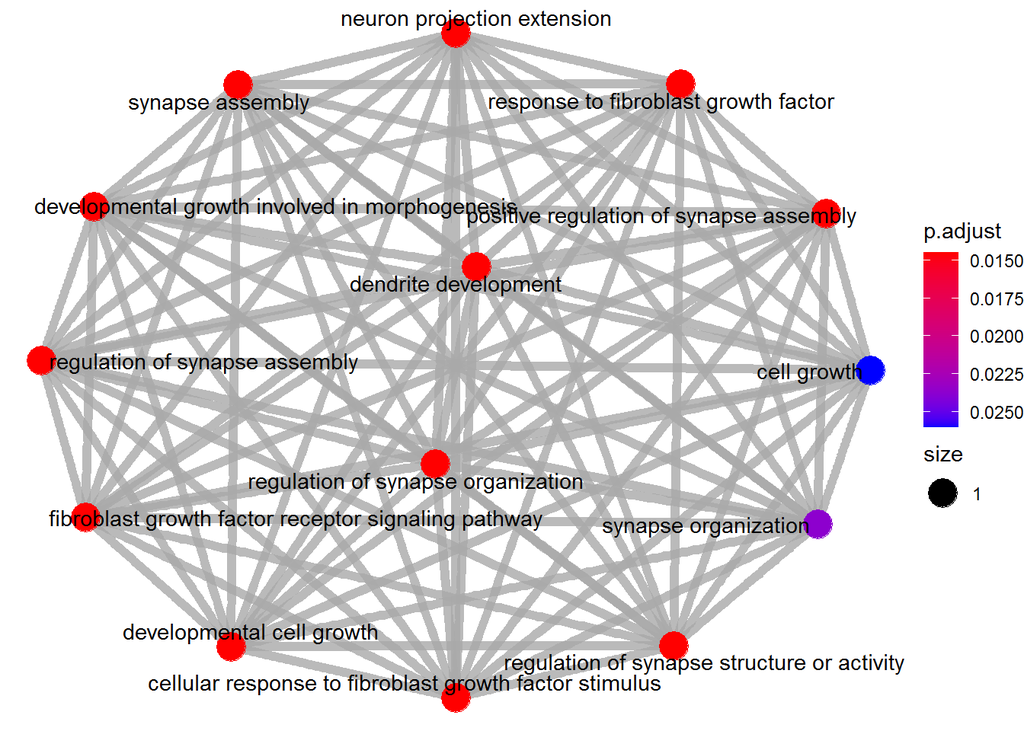

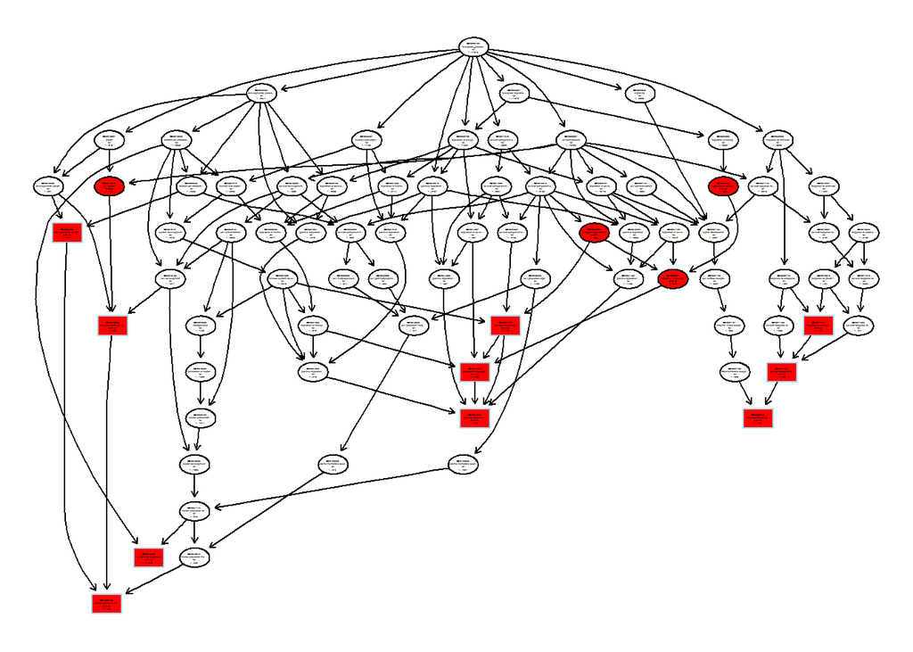

```
$dag
A graphNEL graph with directed edges
Number of Nodes = 78
Number of Edges = 148

$complete.dag
[1] "A graph with 78 nodes."
```

# 5. DISCUSIÓN

# 6. CONCLUSIÓN

Se concluye una posible expresión diferencial de genes entre poblaciores caucásica y africana, de posible interés patogénico y antropológico.